# Time Series Analysis: KSE-100 Index

A Comprehensive Tutorial Following Hyndman’s Approach

Author

# Introduction

## Overview

Welcome to this comprehensive time series analysis tutorial using the **Karachi Stock Exchange (KSE-100) Index**. This tutorial follows the pedagogical approach of Professor Rob J. Hyndman, emphasizing:

- **Visual exploration** before modeling
- **Understanding patterns** in data
- **Systematic decomposition** of time series components
- **Forecasting** with appropriate models

### Learning Objectives

By the end of this tutorial, you will be able to:

1. Load and prepare time series data
2. Create effective visualizations for time series
3. Identify and understand time series components (trend, seasonality, cycles)
4. Decompose time series using classical and modern methods
5. Check for stationarity and transformations
6. Build forecasting models

### The KSE-100 Index

The KSE-100 Index is a stock index acting as a benchmark to compare prices on the Pakistan Stock Exchange over time. It captures the performance of the top 100 companies listed on the exchange.

## Data Description

Our dataset contains daily trading information for the KSE-100 index:

**Variables:**

- `date`: Trading date
- `open`: Opening price
- `high`: Highest price during the day
- `low`: Lowest price during the day
- `close`: Closing price
- `vol`: Trading volume
- `change_percent`: Daily percentage change

**Time Period:** The data spans multiple years of trading activity.

## Setup Requirements

```r
# Required packages
install.packages(c("tidyverse", "fpp3", "tsibble",
                   "feasts", "forecast", "dygraphs",
                   "xts", "zoo", "janitor"))
```

# Data Loading & Preparation

## Load Data

```r
# Load the dataset.
# data/kse_2025.csv is generated from data/kse_oct25.xlsx
# (source: scstrade.com historical indices, Jan 2022 - Oct 2025).
kse_raw <- read_csv("data/kse_2025.csv") %>%
  clean_names()

# Display first few rows
head(kse_raw) %>%
  kable(caption = "First 6 rows of raw KSE-100 data") %>%
  kable_styling(bootstrap_options = c("striped", "hover"))
```

First 6 rows of raw KSE-100 data

| date | price | open | high | low | vol | change_percent |
| --- | --- | --- | --- | --- | --- | --- |
| 10/10/2025 | 163098.2 | 163984.8 | 165262.9 | 162411.2 | 607604107 | -0.87% |
| 10/09/2025 | 164530.8 | 165526.9 | 166730.0 | 164306.8 | 698865320 | -0.45% |
| 10/08/2025 | 165266.7 | 166360.5 | 166947.2 | 165109.8 | 554831161 | -0.55% |
| 10/07/2025 | 166173.7 | 168299.2 | 168519.0 | 165997.2 | 629739254 | -0.94% |
| 10/06/2025 | 167752.4 | 169179.0 | 169326.4 | 165997.4 | 623765222 | -0.73% |
| 10/03/2025 | 168990.1 | 169041.4 | 169988.6 | 168613.4 | 831083556 | 0.30% |

## Data Cleaning

```r
kse <- kse_raw %>%
  mutate(
    # robust date parsing
    date = mdy(trimws(date)),

    # % to numeric
    change_percent = parse_number(change_percent),

    # handle 85.44M / 190.65M / 1.2B / 930K, commas, spaces, etc.
    vol_clean = str_trim(vol),
    vol_base  = parse_number(vol_clean),  # strips commas, keeps number
    vol_mult  = case_when(
      str_detect(vol_clean, regex("M$", ignore_case = TRUE)) ~ 1e6,
      str_detect(vol_clean, regex("B$", ignore_case = TRUE)) ~ 1e9,
      str_detect(vol_clean, regex("K$", ignore_case = TRUE)) ~ 1e3,
      TRUE ~ 1
    ),
    vol = vol_base * vol_mult
  ) %>%
  select(date, open, high, low, vol, change_percent) %>%
  arrange(date) %>%
  tidyr::drop_na()

# Create tsibble object (tidy time series)
kse_tsbl <- kse %>%
  as_tsibble(index = date)

# Summary statistics
summary(kse) %>%
  kable(caption = "Summary Statistics of KSE-100 Variables") %>%
  kable_styling(bootstrap_options = c("striped", "hover"))
```

Summary Statistics of KSE-100 Variables

|  | date | open | high | low | vol | change_percent |
| --- | --- | --- | --- | --- | --- | --- |
|  | Min. :2022-01-04 | Min. : 38348 | Min. : 38553 | Min. : 38136 | Min. :4.742e+04 | Min. :-18.5100 |
|  | 1st Qu.:2022-12-13 | 1st Qu.: 42358 | 1st Qu.: 42592 | 1st Qu.: 42079 | 1st Qu.:9.282e+07 | 1st Qu.: -0.4000 |
|  | Median :2023-11-22 | Median : 57504 | Median : 58406 | Median : 57419 | Median :1.562e+08 | Median : 0.1300 |
|  | Mean :2023-11-22 | Mean : 70968 | Mean : 71429 | Mean : 70506 | Mean :2.009e+08 | Mean : 0.1491 |
|  | 3rd Qu.:2024-11-04 | 3rd Qu.: 91454 | 3rd Qu.: 92159 | 3rd Qu.: 91395 | 3rd Qu.:2.569e+08 | 3rd Qu.: 0.7400 |
|  | Max. :2025-10-10 | Max. :169179 | Max. :169989 | Max. :168613 | Max. :1.027e+09 | Max. : 22.1800 |

## Data Structure

```r
# Display structure
glimpse(kse_tsbl)
```

```
Rows: 933
Columns: 6
$ date           <date> 2022-01-04, 2022-01-05, 2022-01-06, 2022-01-07, 2022-0…
$ open           <dbl> 44947.73, 45409.48, 45396.46, 45022.16, 45345.77, 45926…
$ high           <dbl> 45406.08, 45438.16, 45407.89, 45364.19, 45967.29, 46057…
$ low            <dbl> 44886.89, 45241.45, 45021.32, 44968.90, 45206.00, 45524…
$ vol            <dbl> 134143464, 96600200, 132060208, 84107744, 126790816, 10…
$ change_percent <dbl> 1.12, 0.04, -0.72, 0.58, 1.20, -0.01, 0.08, -0.33, 0.00…
```

```r
# Check for gaps in the time series
has_gaps(kse_tsbl)
```

| .gaps |
| --- |
| TRUE |

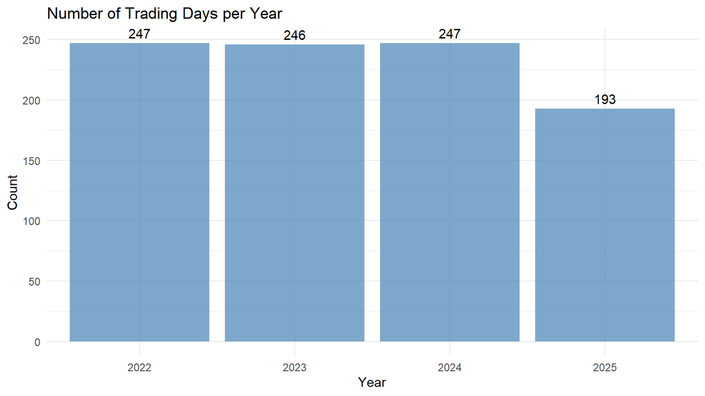

```r
# Count observations by year
kse_tsbl %>%
  mutate(year = year(date)) %>%
  count(year) %>%
  ggplot(aes(x = factor(year), y = n)) +
  geom_col(fill = "steelblue", alpha = 0.7) +
  geom_text(aes(label = n), vjust = -0.5) +
  labs(title = "Number of Trading Days per Year",
       x = "Year", y = "Count") +
  theme_minimal()
```

# Visual Exploration

## Time Plot

> “The first thing to do in any data analysis task is to plot the data.” - Rob J. Hyndman

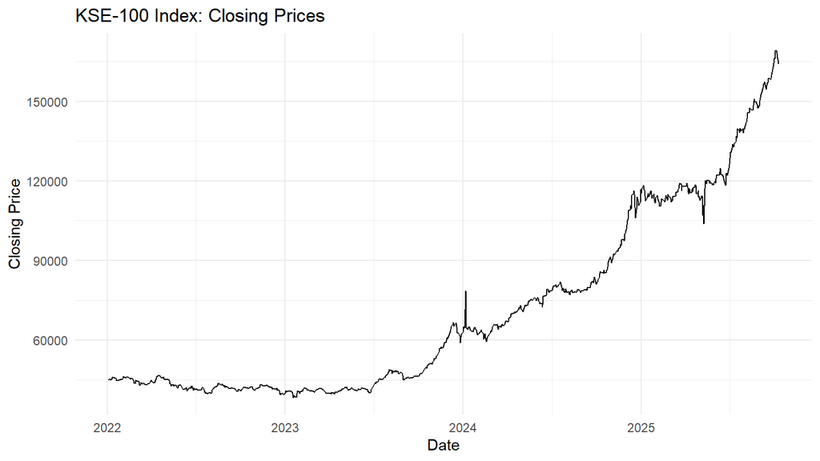

```r
# Static time plot
kse_tsbl %>%
  autoplot(open) +
  labs(title = "KSE-100 Index: Closing Prices",
       y = "Closing Price",
       x = "Date") +
  theme_minimal()
```

```r
# Interactive time plot
kse_xts <- xts(kse$open, order.by = kse$date)
dygraph(kse_xts, main = "KSE-100 Index (Interactive)") %>%
  dyAxis("y", label = "Close Price") %>%
  dyRangeSelector() %>%
  dyOptions(colors = "#2C3E50", strokeWidth = 1.5)
```

[interactive chart not shown]

**Key Observations:**

- Identify overall trend direction
- Note any major jumps or crashes
- Look for periods of high volatility
- Observe general price levels across time

## Multiple Variables

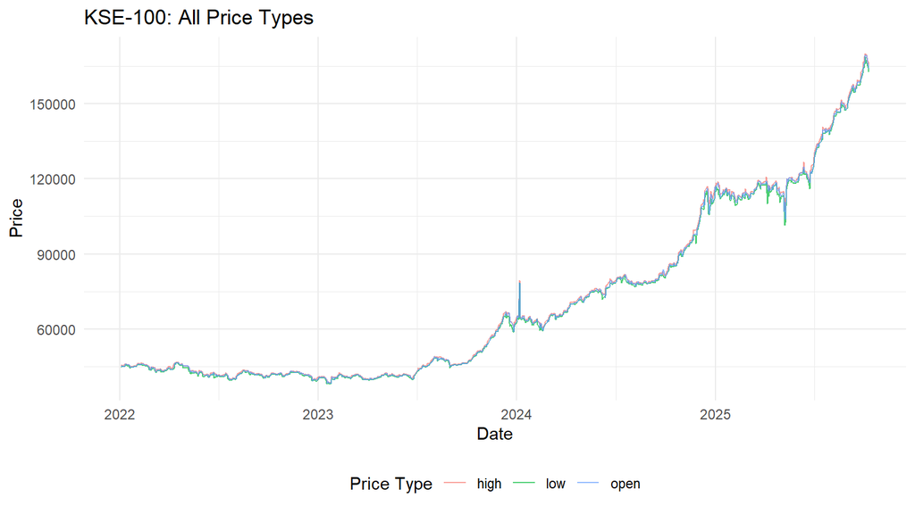

```r
# Plot all price variables
kse_tsbl %>%
  select(date, open, high, low) %>%
  pivot_longer(cols = -date, names_to = "price_type", values_to = "price") %>%
  ggplot(aes(x = date, y = price, color = price_type)) +
  geom_line(alpha = 0.7) +
  labs(title = "KSE-100: All Price Types",
       y = "Price", x = "Date",
       color = "Price Type") +
  theme_minimal() +
  theme(legend.position = "bottom")
```

## Daily Returns

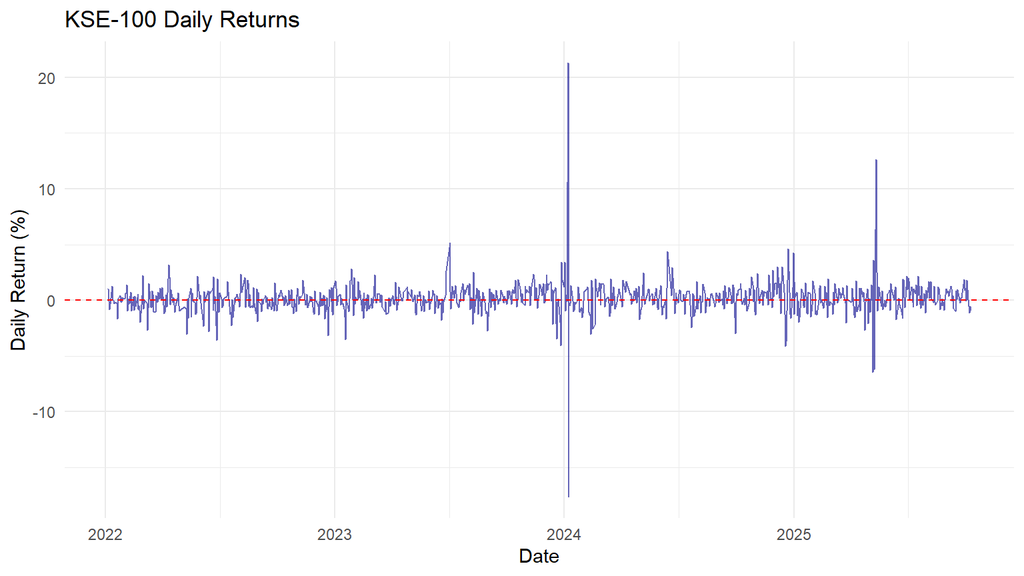

```r
# Calculate daily returns
kse_returns <- kse_tsbl %>%
  mutate(
    daily_return = (open - lag(open)) / lag(open) * 100,
    abs_return = abs(daily_return)
  )

# Plot returns
kse_returns %>%
  ggplot(aes(x = date, y = daily_return)) +
  geom_line(color = "darkblue", alpha = 0.6) +
  geom_hline(yintercept = 0, color = "red", linetype = "dashed") +
  labs(title = "KSE-100 Daily Returns",
       y = "Daily Return (%)",
       x = "Date") +
  theme_minimal()
```

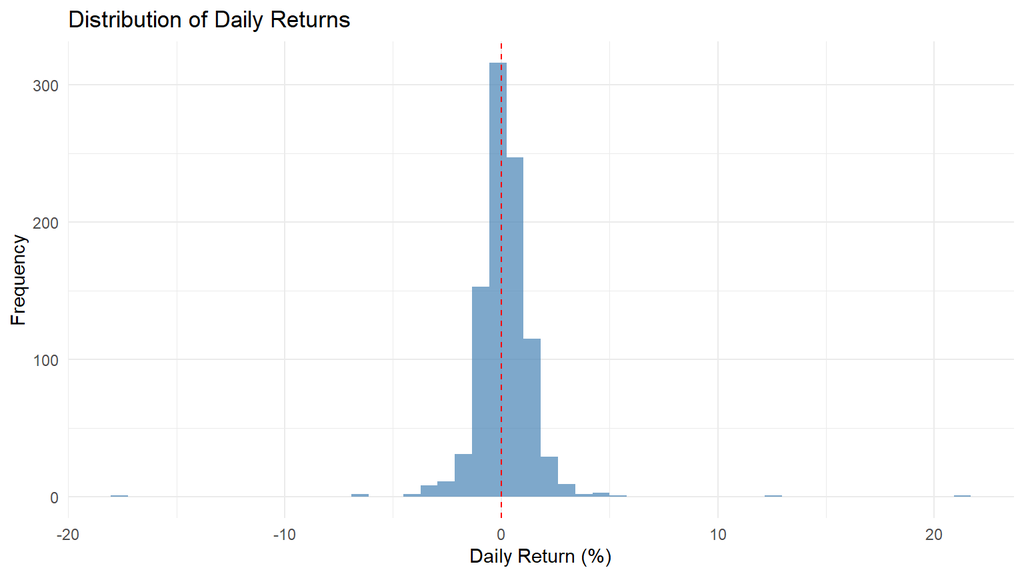

```r
# Distribution of returns
kse_returns %>%
  ggplot(aes(x = daily_return)) +
  geom_histogram(bins = 50, fill = "steelblue", alpha = 0.7) +
  geom_vline(xintercept = 0, color = "red", linetype = "dashed") +
  labs(title = "Distribution of Daily Returns",
       x = "Daily Return (%)",
       y = "Frequency") +
  theme_minimal()
```

## Volume Analysis

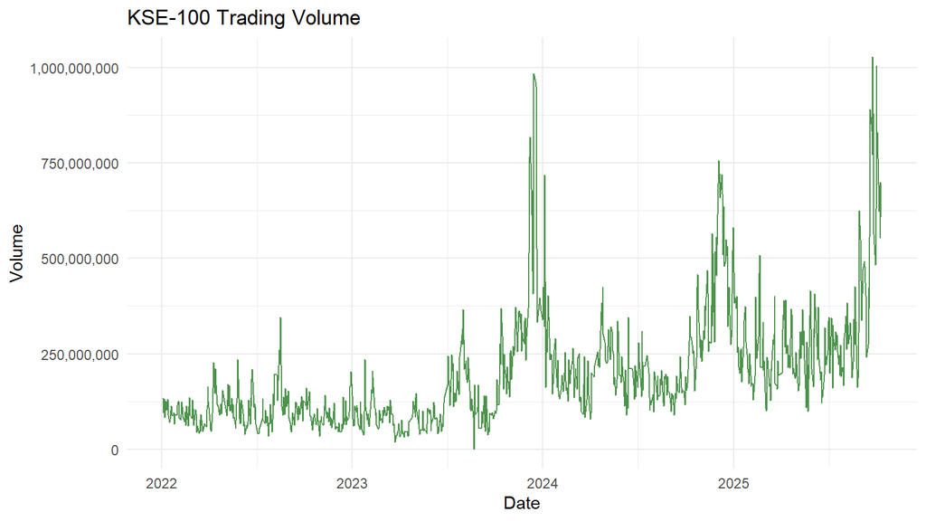

```r
# Volume over time
kse_tsbl %>%
  ggplot(aes(x = date, y = vol)) +
  geom_line(color = "darkgreen", alpha = 0.7) +
  labs(title = "KSE-100 Trading Volume",
       y = "Volume",
       x = "Date") +
  scale_y_continuous(labels = scales::comma) +
  theme_minimal()
```

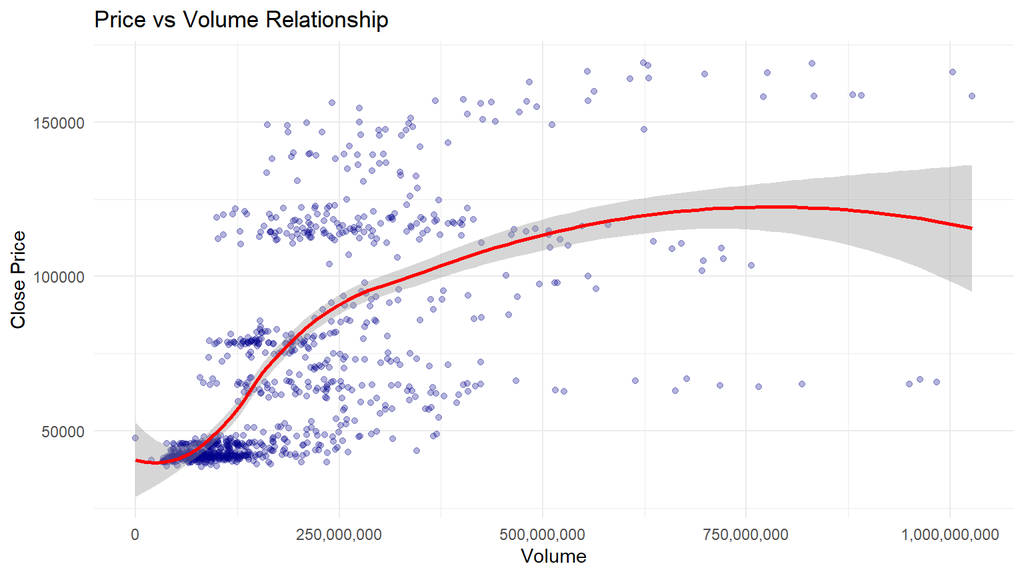

```r
# Price vs Volume relationship
kse_tsbl %>%
  ggplot(aes(x = vol, y = open)) +
  geom_point(alpha = 0.3, color = "darkblue") +
  geom_smooth(method = "loess", color = "red") +
  labs(title = "Price vs Volume Relationship",
       x = "Volume",
       y = "Close Price") +
  scale_x_continuous(labels = scales::comma) +
  theme_minimal()
```

# Seasonal Patterns

## Seasonal Plots

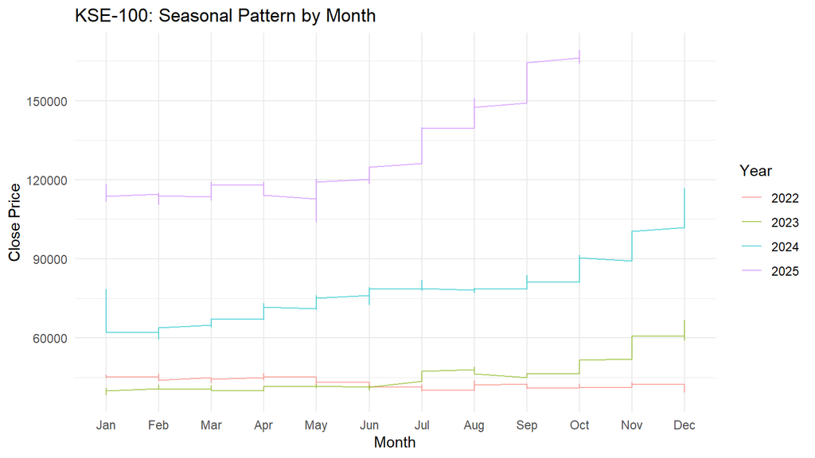

```r
# Add time features
kse_seasonal <- kse_tsbl %>%
  mutate(
    year = year(date),
    month = month(date, label = TRUE),
    week = week(date),
    wday = wday(date, label = TRUE)
  )

# Monthly patterns
kse_seasonal %>%
  ggplot(aes(x = month, y = open, group = year, color = factor(year))) +
  geom_line(alpha = 0.6) +
  labs(title = "KSE-100: Seasonal Pattern by Month",
       x = "Month", y = "Close Price",
       color = "Year") +
  theme_minimal() +
  theme(legend.position = "right")
```

## Day of Week Effects

[figure not shown]

```r
# Day of week analysis
weekday_summary <- kse_returns %>%
  mutate(wday = wday(date, label = TRUE)) %>%
  group_by(wday) %>%
  summarise(
    avg_return = mean(daily_return, na.rm = TRUE),
    sd_return = sd(daily_return, na.rm = TRUE),
    n = n()
  )

weekday_summary %>%
  ggplot(aes(x = wday, y = avg_return)) +
  geom_col(fill = "steelblue", alpha = 0.7) +
  geom_errorbar(aes(ymin = avg_return - sd_return,
                    ymax = avg_return + sd_return),
                width = 0.2) +
  geom_hline(yintercept = 0, linetype = "dashed", color = "red") +
  labs(title = "Average Daily Returns by Day of Week",
       x = "Day of Week",
       y = "Average Return (%)") +
  theme_minimal()
```

```r
#weekday_summary %>%
 ##      col.names = c("Day", "Avg Return (%)", "Std Dev", "Count"),
   #     digits = 3) %>%
  #able_styling(bootstrap_options = c("striped", "hover"))
```

## Monthly Aggregation

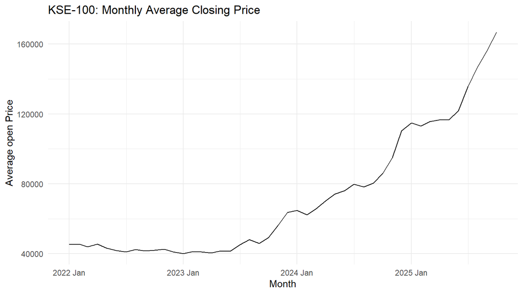

```r
# Aggregate to monthly data
kse_monthly <- kse_tsbl %>%
  mutate(year_month = yearmonth(date)) %>%
  as_tibble() %>%  # Convert to tibble first to remove tsibble structure
  group_by(year_month) %>%
  summarise(
    avg_open = mean(open, na.rm = TRUE),
    max_open = max(open, na.rm = TRUE),
    min_open = min(open, na.rm = TRUE),
    total_vol = sum(vol, na.rm = TRUE),
    .groups = "drop"  # Automatically drop grouping
  ) %>%
  as_tsibble(index = year_month)

# Plot monthly average
kse_monthly %>%
  autoplot(avg_open) +
  labs(title = "KSE-100: Monthly Average Closing Price",
       y = "Average open Price",
       x = "Month") +
  theme_minimal()
```

# Decomposition

## Classical Decomposition

```r
# Check if we have enough data for classical decomposition
n_months <- nrow(kse_monthly)
cat("Number of months available:", n_months, "\n")
```

```
Number of months available: 46
```

```r
# Classical decomposition requires at least 2 complete periods (24 months)
if (n_months >= 24) {
  # Monthly data decomposition
  dcmp_classical <- kse_monthly %>%
    model(
      classical = classical_decomposition(avg_open, type = "additive")
    )

  # Plot components
  components(dcmp_classical) %>%
    autoplot() +
    labs(title = "Classical Decomposition: KSE-100 Monthly Average") +
    theme_minimal()

  # Extract components
  components(dcmp_classical) %>%
    as_tibble() %>%
    head(12) %>%
    kable(caption = "First 12 months of decomposed components",
          digits = 2) %>%
    kable_styling(bootstrap_options = c("striped", "hover"))
} else {
  cat("⚠️ Not enough data for classical decomposition.\n")
  cat("Need at least 24 months, have", n_months, "months.\n\n")
  cat("Using a simple trend extraction instead:\n\n")

  # Alternative: simple moving average trend
  kse_monthly %>%
    mutate(
      trend = slider::slide_dbl(avg_open, mean,
                                .before = 2, .after = 2, .complete = TRUE)
    ) %>%
    pivot_longer(cols = c(avg_open, trend),
                 names_to = "component",
                 values_to = "value") %>%
    ggplot(aes(x = year_month, y = value, color = component)) +
    geom_line(size = 1) +
    scale_color_manual(values = c("avg_open" = "gray60", "trend" = "darkblue"),
                      labels = c("avg_open" = "Original", "trend" = "Trend (5-MA)")) +
    labs(title = "KSE-100: Original Series with Trend",
         y = "Average open Price",
         x = "Month",
         color = "") +
    theme_minimal() +
    theme(legend.position = "bottom")
}
```

First 12 months of decomposed components

| .model | year_month | avg_open | trend | seasonal | random | season_adjust |
| --- | --- | --- | --- | --- | --- | --- |
| classical | 2022 Jan | 45317.20 | NA | 4798.99 | NA | 40518.21 |
| classical | 2022 Feb | 45525.61 | NA | 953.66 | NA | 44571.95 |
| classical | 2022 Mar | 43845.18 | NA | -144.16 | NA | 43989.34 |
| classical | 2022 Apr | 45528.11 | NA | -1866.20 | NA | 47394.31 |
| classical | 2022 May | 43106.09 | NA | 314.90 | NA | 42791.19 |
| classical | 2022 Jun | 41875.98 | NA | -1368.38 | NA | 43244.36 |
| classical | 2022 Jul | 40918.86 | 42749.12 | -738.06 | -1092.20 | 41656.92 |
| classical | 2022 Aug | 42451.73 | 42348.10 | -1739.07 | 1842.70 | 44190.80 |
| classical | 2022 Sep | 41673.83 | 42046.70 | -3913.94 | 3541.07 | 45587.77 |
| classical | 2022 Oct | 41894.61 | 41710.83 | -2778.52 | 2962.30 | 44673.13 |
| classical | 2022 Nov | 42506.34 | 41431.67 | 782.24 | 292.43 | 41724.10 |
| classical | 2022 Dec | 40979.27 | 41345.47 | 5698.55 | -6064.74 | 35280.73 |

## STL Decomposition

> “STL (Seasonal and Trend decomposition using Loess) is a versatile and robust method for decomposing time series.” - Hyndman

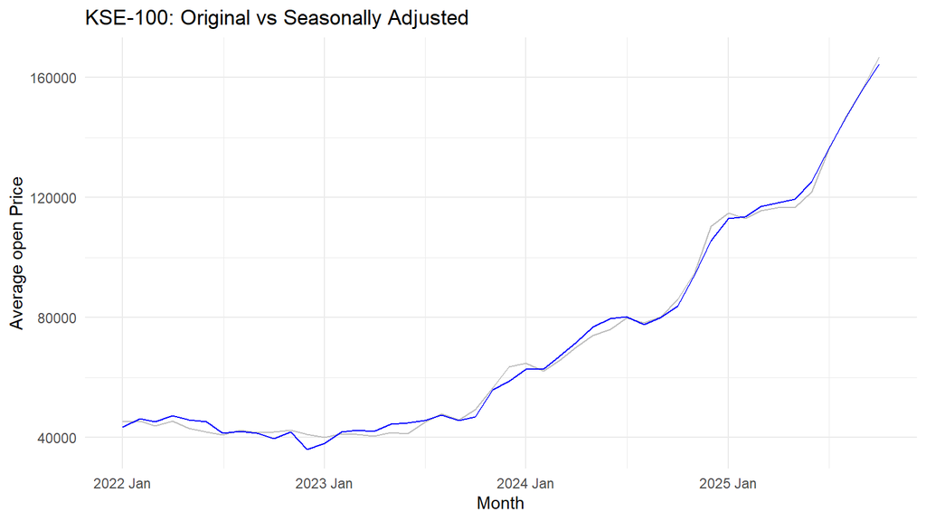

```r
# STL decomposition also requires sufficient data
if (n_months >= 24) {
  # STL decomposition
  dcmp_stl <- kse_monthly %>%
    model(
      stl = STL(avg_open ~ season(window = "periodic"))
    )

  # Plot STL components
  components(dcmp_stl) %>%
    autoplot() +
    labs(title = "STL Decomposition: KSE-100 Monthly Average") +
    theme_minimal()

  # Seasonally adjusted series
  kse_monthly %>%
    autoplot(avg_open, color = "gray") +
    autolayer(components(dcmp_stl), season_adjust, color = "blue") +
    labs(title = "KSE-100: Original vs Seasonally Adjusted",
         y = "Average open Price",
         x = "Month") +
    theme_minimal()
} else {
  cat("⚠️ Not enough data for STL decomposition.\n")
  cat("Using alternative trend-cycle extraction:\n\n")

  # Use a simple loess smoother for trend
  kse_monthly %>%
    mutate(
      trend = predict(loess(avg_open ~ as.numeric(year_month),
                           data = ., span = 0.3))
    ) %>%
    ggplot(aes(x = year_month)) +
    geom_line(aes(y = avg_open), color = "gray60", alpha = 0.7) +
    geom_line(aes(y = trend), color = "darkred", size = 1.2) +
    labs(title = "KSE-100: Original Series with LOESS Trend",
         y = "Average open Price",
         x = "Month") +
    theme_minimal()
}
```

## Trend Analysis

```r
# Extract and analyze trend
if (exists("dcmp_stl") && n_months >= 24) {
  trend_data <- components(dcmp_stl) %>%
    as_tibble() %>%
    select(year_month, trend)

  # Plot trend with confidence interval
  ggplot(trend_data, aes(x = year_month, y = trend)) +
    geom_line(color = "darkblue", size = 1) +
    geom_smooth(method = "loess", color = "red", fill = "pink", alpha = 0.3) +
    labs(title = "KSE-100 Trend Component with Smoothed Trend",
         y = "Trend",
         x = "Month") +
    theme_minimal()

  # Calculate trend statistics
  trend_stats <- trend_data %>%
    summarise(
      min_trend = min(trend, na.rm = TRUE),
      max_trend = max(trend, na.rm = TRUE),
      avg_trend = mean(trend, na.rm = TRUE),
      trend_range = max_trend - min_trend,
      pct_change = (max_trend - min_trend) / min_trend * 100
    )

  trend_stats %>%
    kable(caption = "Trend Component Statistics",
          digits = 2) %>%
    kable_styling(bootstrap_options = c("striped", "hover"))
} else {
  # Alternative trend analysis using moving average
  kse_monthly %>%
    mutate(
      ma_3 = slider::slide_dbl(avg_open, mean, .before = 1, .after = 1, .complete = TRUE),
      ma_6 = slider::slide_dbl(avg_open, mean, .before = 2, .after = 2, .complete = TRUE)
    ) %>%
    pivot_longer(cols = c(avg_open, ma_3, ma_6),
                 names_to = "series",
                 values_to = "value") %>%
    ggplot(aes(x = year_month, y = value, color = series)) +
    geom_line(size = 1) +
    scale_color_manual(
      values = c("avg_open" = "gray50", "ma_3" = "blue", "ma_6" = "darkred"),
      labels = c("avg_open" = "Original", "ma_3" = "3-Month MA", "ma_6" = "6-Month MA")
    ) +
    labs(title = "KSE-100: Trend Extraction using Moving Averages",
         y = "Average open Price",
         x = "Month",
         color = "") +
    theme_minimal() +
    theme(legend.position = "bottom")

  # Simple trend statistics
  kse_monthly %>%
    summarise(
      first_value = first(avg_open),
      last_value = last(avg_open),
      min_value = min(avg_open),
      max_value = max(avg_open),
      total_change = last_value - first_value,
      pct_change = (last_value - first_value) / first_value * 100
    ) %>%
    kable(caption = "Overall Trend Statistics",
          digits = 2) %>%
    kable_styling(bootstrap_options = c("striped", "hover"))
}
```

Trend Component Statistics

| min_trend | max_trend | avg_trend | trend_range | pct_change |
| --- | --- | --- | --- | --- |
| 41271.2 | 157084.7 | 73066.35 | 115813.5 | 280.62 |

# Autocorrelation

## ACF Analysis

[figure not shown]

```r
# Note: Stock market data has irregular gaps (weekends, holidays)
# We need to use fill_gaps() or work with the index directly

# ACF plot for closing prices
kse_tsbl %>%
  fill_gaps() %>%  # Fill gaps with NA
  ACF(open, lag_max = 50) %>%
  autoplot() +
  labs(title = "ACF: KSE-100 Closing Prices",
       subtitle = "Strong persistence indicates non-stationarity") +
  theme_minimal()
```

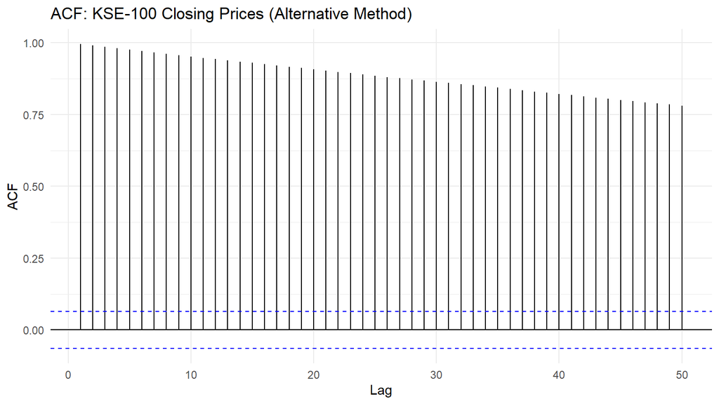

```r
# Alternative: Use acf() from stats package with regular spacing
acf_open <- acf(kse$open, lag.max = 50, plot = FALSE)
autoplot(acf_open) +
  labs(title = "ACF: KSE-100 Closing Prices (Alternative Method)",
       x = "Lag", y = "ACF") +
  theme_minimal()
```

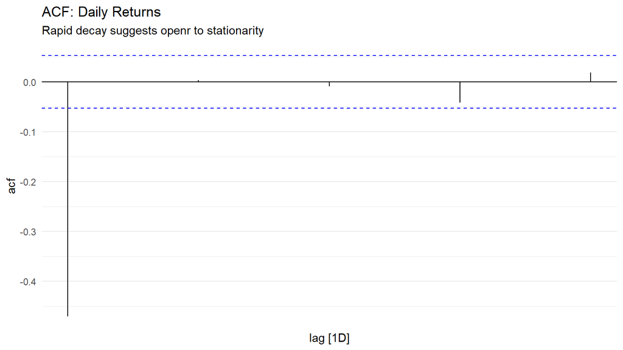

```r
# ACF for returns
kse_returns %>%
  fill_gaps() %>%
  ACF(daily_return, lag_max = 50) %>%
  autoplot() +
  labs(title = "ACF: Daily Returns",
       subtitle = "Rapid decay suggests openr to stationarity") +
  theme_minimal()
```

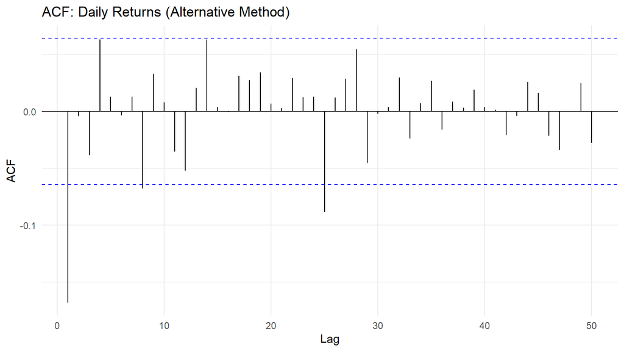

```r
# Alternative for returns
returns_clean <- na.omit(kse_returns$daily_return)
acf_returns <- acf(returns_clean, lag.max = 50, plot = FALSE)
autoplot(acf_returns) +
  labs(title = "ACF: Daily Returns (Alternative Method)",
       x = "Lag", y = "ACF") +
  theme_minimal()
```

**Interpretation:**

## PACF Analysis

[figure not shown]

```r
# PACF plot for closing prices
kse_tsbl %>%
  fill_gaps() %>%
  PACF(open, lag_max = 50) %>%
  autoplot() +
  labs(title = "PACF: KSE-100 Closing Prices",
       subtitle = "High lag-1 value indicates strong AR component") +
  theme_minimal()
```

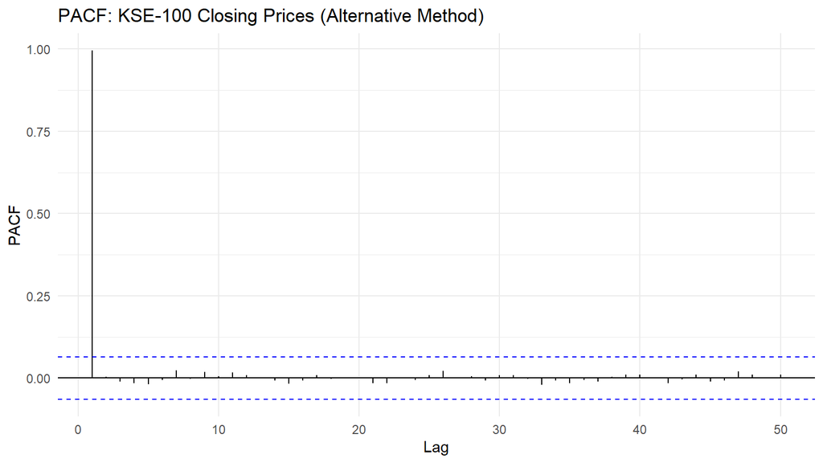

```r
# Alternative method
pacf_open <- pacf(kse$open, lag.max = 50, plot = FALSE)
autoplot(pacf_open) +
  labs(title = "PACF: KSE-100 Closing Prices (Alternative Method)",
       x = "Lag", y = "PACF") +
  theme_minimal()
```

[figure not shown]

```r
# PACF for returns
kse_returns %>%
  fill_gaps() %>%
  PACF(daily_return, lag_max = 50) %>%
  autoplot() +
  labs(title = "PACF: Daily Returns",
       subtitle = "Values within confidence bands suggest white noise") +
  theme_minimal()
```

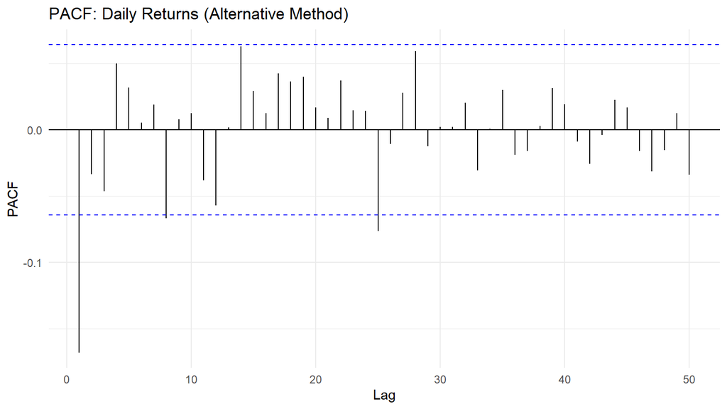

```r
# Alternative for returns
pacf_returns <- pacf(returns_clean, lag.max = 50, plot = FALSE)
autoplot(pacf_returns) +
  labs(title = "PACF: Daily Returns (Alternative Method)",
       x = "Lag", y = "PACF") +
  theme_minimal()
```

## Ljung-Box Test

```r
# Ljung-Box test for returns (using filled gaps)
kse_returns_filled <- kse_returns %>%
  fill_gaps() %>%
  fill(daily_return, .direction = "down")  # Fill NA with previous value

lb_test <- kse_returns_filled %>%
  features(daily_return, ljung_box, lag = 20, dof = 0)

lb_test %>%
  kable(caption = "Ljung-Box Test Results for Daily Returns",
        digits = 4,
        col.names = c("Statistic", "P-value")) %>%
  kable_styling(bootstrap_options = c("striped", "hover"))
```

Ljung-Box Test Results for Daily Returns

| Statistic | P-value |
| --- | --- |
| 61.0955 | 0 |

```r
# Interpretation
cat("\n**Test Result:**\n\n")
```

```
**Test Result:**
```

```r
if(lb_test$lb_pvalue < 0.05) {
  cat("✓ The returns show significant autocorrelation (p < 0.05)\n")
  cat("  → There is predictable structure in returns\n")
  cat("  → ARIMA models may be appropriate\n")
} else {
  cat("✗ No significant autocorrelation in returns (p ≥ 0.05)\n")
  cat("  → Returns appear to be white noise\n")
  cat("  → Market may be informationally efficient\n")
}
```

```
✓ The returns show significant autocorrelation (p < 0.05)
  → There is predictable structure in returns
  → ARIMA models may be appropriate
```

```r
# Additional test on squared returns (test for ARCH effects)
kse_returns_sq <- kse_returns_filled %>%
  mutate(sq_return = daily_return^2)

lb_test_sq <- kse_returns_sq %>%
  features(sq_return, ljung_box, lag = 20, dof = 0)

cat("\n\n**Ljung-Box Test on Squared Returns:**\n\n")
```

```
**Ljung-Box Test on Squared Returns:**
```

```r
lb_test_sq %>%
  kable(caption = "Testing for Volatility Clustering (ARCH Effects)",
        digits = 4,
        col.names = c("Statistic", "P-value")) %>%
  kable_styling(bootstrap_options = c("striped", "hover"))
```

Testing for Volatility Clustering (ARCH Effects)

| Statistic | P-value |
| --- | --- |
| 287.1568 | 0 |

```r
if(lb_test_sq$lb_pvalue < 0.05) {
  cat("\n✓ Significant autocorrelation in squared returns\n")
  cat("  → Volatility clustering present\n")
  cat("  → GARCH models may be appropriate\n")
}
```

```
✓ Significant autocorrelation in squared returns
  → Volatility clustering present
  → GARCH models may be appropriate
```

# Stationarity Testing

## Visual Tests

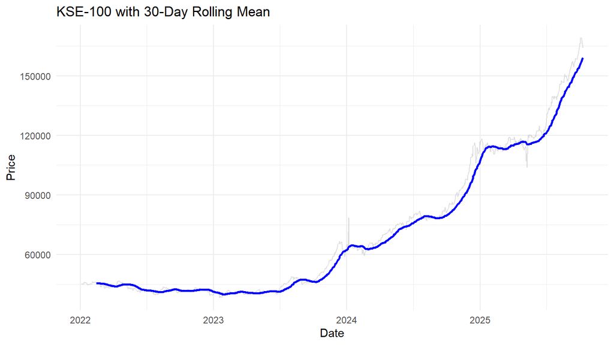

```r
# Plot with rolling mean and std
kse_rolling <- kse_tsbl %>%
  mutate(
    roll_mean = slider::slide_dbl(open, mean, .before = 29, .complete = TRUE),
    roll_sd = slider::slide_dbl(open, sd, .before = 29, .complete = TRUE)
  )

# Rolling mean
ggplot(kse_rolling, aes(x = date)) +
  geom_line(aes(y = open), alpha = 0.5, color = "gray") +
  geom_line(aes(y = roll_mean), color = "blue", size = 1) +
  labs(title = "KSE-100 with 30-Day Rolling Mean",
       y = "Price", x = "Date") +
  theme_minimal()
```

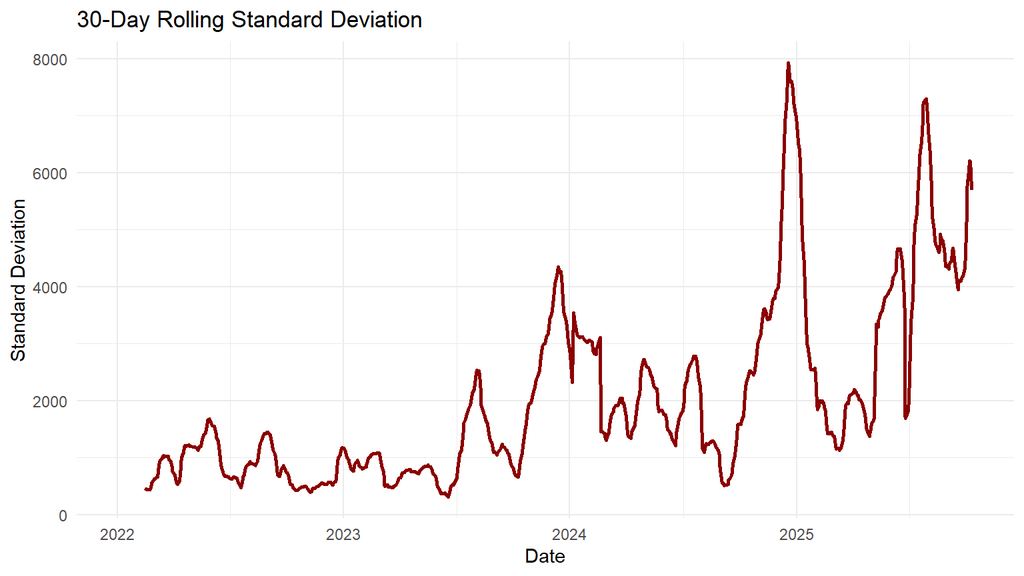

```r
# Rolling standard deviation
ggplot(kse_rolling, aes(x = date, y = roll_sd)) +
  geom_line(color = "darkred", size = 1) +
  labs(title = "30-Day Rolling Standard Deviation",
       y = "Standard Deviation", x = "Date") +
  theme_minimal()
```

## Unit Root Tests

```r
# ADF test function
adf_test <- function(x) {
  test <- tseries::adf.test(x, alternative = "stationary")
  tibble(
    statistic = test$statistic,
    p_value = test$p.value,
    conclusion = ifelse(test$p.value < 0.05, "Stationary", "Non-Stationary")
  )
}

# KPSS test function
kpss_test <- function(x) {
  test <- tseries::kpss.test(x)
  tibble(
    statistic = test$statistic,
    p_value = test$p.value,
    conclusion = ifelse(test$p.value < 0.05, "Non-Stationary", "Stationary")
  )
}

# Test closing prices
cat("Tests for Closing Prices:\n\n")
```

```
Tests for Closing Prices:
```

```r
adf_open <- adf_test(na.omit(kse$open))
kpss_open <- kpss_test(na.omit(kse$open))

bind_rows(
  adf_open %>% mutate(test = "ADF"),
  kpss_open %>% mutate(test = "KPSS")
) %>%
  select(test, everything()) %>%
  kable(caption = "Stationarity Tests: Closing Prices",
        digits = 4) %>%
  kable_styling(bootstrap_options = c("striped", "hover"))
```

| test | statistic | p_value | conclusion |
| --- | --- | --- | --- |
| ADF | 0.1951 | 0.99 | Non-Stationary |
| KPSS | 11.4699 | 0.01 | Non-Stationary |

```r
# Test returns
cat("\nTests for Daily Returns:\n\n")
```

```
Tests for Daily Returns:
```

```r
returns_clean <- na.omit(kse_returns$daily_return)
adf_returns <- adf_test(returns_clean)
kpss_returns <- kpss_test(returns_clean)

bind_rows(
  adf_returns %>% mutate(test = "ADF"),
  kpss_returns %>% mutate(test = "KPSS")
) %>%
  select(test, everything()) %>%
  kable(caption = "Stationarity Tests: Daily Returns",
        digits = 4) %>%
  kable_styling(bootstrap_options = c("striped", "hover"))
```

Stationarity Tests: Daily Returns

| test | statistic | p_value | conclusion |
| --- | --- | --- | --- |
| ADF | -10.1522 | 0.01 | Stationary |
| KPSS | 0.8119 | 0.01 | Non-Stationary |

## Differencing

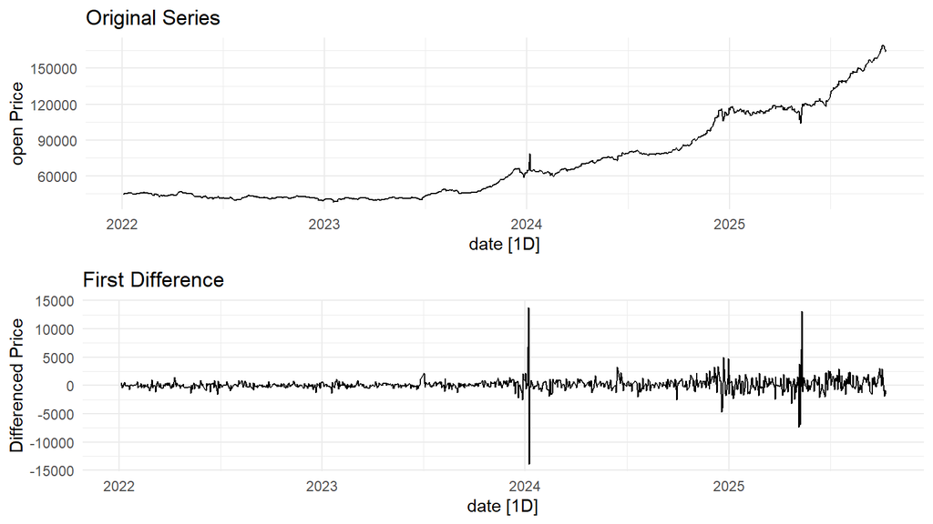

```r
# First difference
kse_diff <- kse_tsbl %>%
  mutate(diff_open = difference(open))

# Plot original and differenced series
p1 <- kse_tsbl %>%
  autoplot(open) +
  labs(title = "Original Series", y = "open Price") +
  theme_minimal()

p2 <- kse_diff %>%
  autoplot(diff_open) +
  labs(title = "First Difference", y = "Differenced Price") +
  theme_minimal()

gridExtra::grid.arrange(p1, p2, ncol = 1)
```

```r
# Test differenced series
diff_clean <- na.omit(kse_diff$diff_open)
cat("Stationarity tests for differenced series:\n\n")
```

```
Stationarity tests for differenced series:
```

```r
bind_rows(
  adf_test(diff_clean) %>% mutate(test = "ADF"),
  kpss_test(diff_clean) %>% mutate(test = "KPSS")
) %>%
  select(test, everything()) %>%
  kable(caption = "Stationarity Tests: First Difference",
        digits = 4) %>%
  kable_styling(bootstrap_options = c("striped", "hover"))
```

Stationarity Tests: First Difference

| test | statistic | p_value | conclusion |
| --- | --- | --- | --- |
| ADF | -10.6620 | 0.01 | Stationary |
| KPSS | 1.3851 | 0.01 | Non-Stationary |